# Laboratório 5 - Checkpoint 2

```r
require(tidyverse)
require(broom)
require(modelr)
```

Nesse laboratório estaremos usando um dataset com informações de professores onde esses dados foram coletados a partir das avaliações discentes de final de semestre de uma grande amostra de professores da Universidade do Texas em Austin. Além disso, seis estudantes avaliaram a aparência física dos professores. No dataset, cada coluna representa as variáveis sobre as disciplinas e os professores.

Algumas variáveis encontradas são:

- Score: pontuação média da avaliação do docente: (1) muito insatisfatóri - (5) excelente
- Rank: nível do professor
- Ethnicity: etnia do professor (minoria ou não minoria)
- Gender: gênero feminino ou masculino
- Age: idade do professor
- Bty_avg: média das avaliações sobre a beleza do professor

Temos como principal objetivo utilizar regressão linear com a finalidade de entender o impacto de algumas variáveis no *score* do professor.

```r
eval = read_csv(file = "../data/evals.csv")
head(eval)
```

```
## # A tibble: 6 x 21
##   score         rank    ethnicity gender language   age cls_perc_eval
##   <dbl>        <chr>        <chr>  <chr>    <chr> <int>         <dbl>
## 1   4.7 tenure track     minority female  english    36      55.81395
## 2   4.1 tenure track     minority female  english    36      68.80000
## 3   3.9 tenure track     minority female  english    36      60.80000
## 4   4.8 tenure track     minority female  english    36      62.60163
## 5   4.6      tenured not minority   male  english    59      85.00000
## 6   4.3      tenured not minority   male  english    59      87.50000
## # ... with 14 more variables: cls_did_eval <int>, cls_students <int>,
## #   cls_level <chr>, cls_profs <chr>, cls_credits <chr>,
## #   bty_f1lower <int>, bty_f1upper <int>, bty_f2upper <int>,
## #   bty_m1lower <int>, bty_m1upper <int>, bty_m2upper <int>,
## #   bty_avg <dbl>, pic_outfit <chr>, pic_color <chr>
```

## Descritivo dos dados

Vamos dar uma olhada no compartamento das variáveis que usaremos mais a frente.

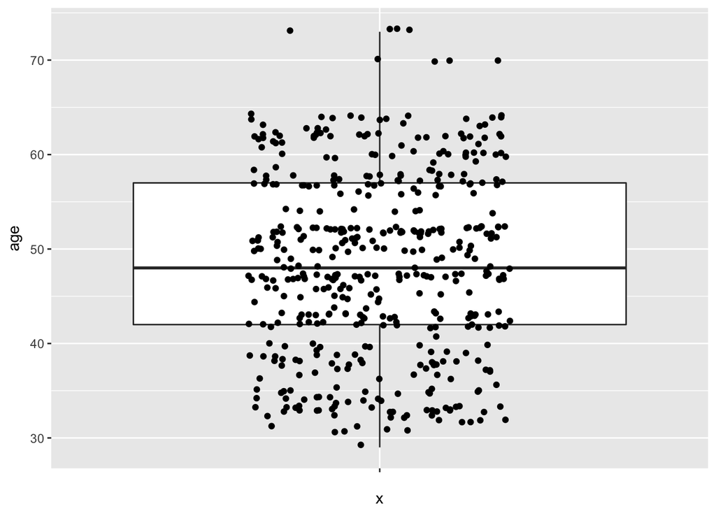

```r
ggplot(eval, aes("", age)) + geom_boxplot() + geom_jitter(width = 0.2)
```

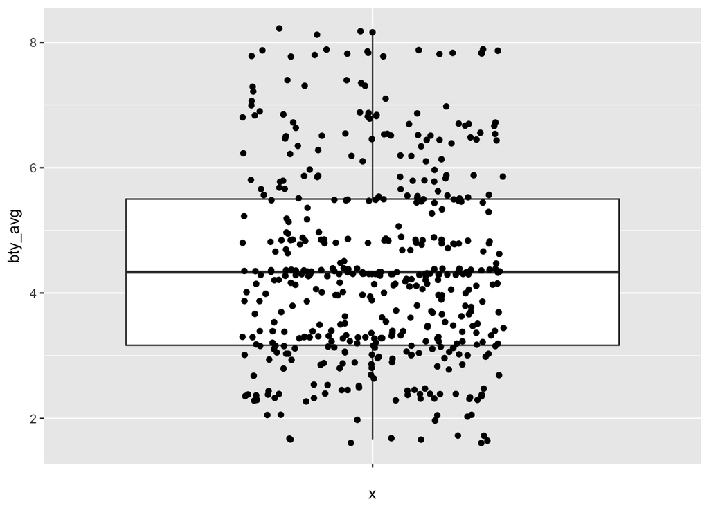

```r
ggplot(eval, aes("", bty_avg)) + geom_boxplot() + geom_jitter(width = 0.2)
```

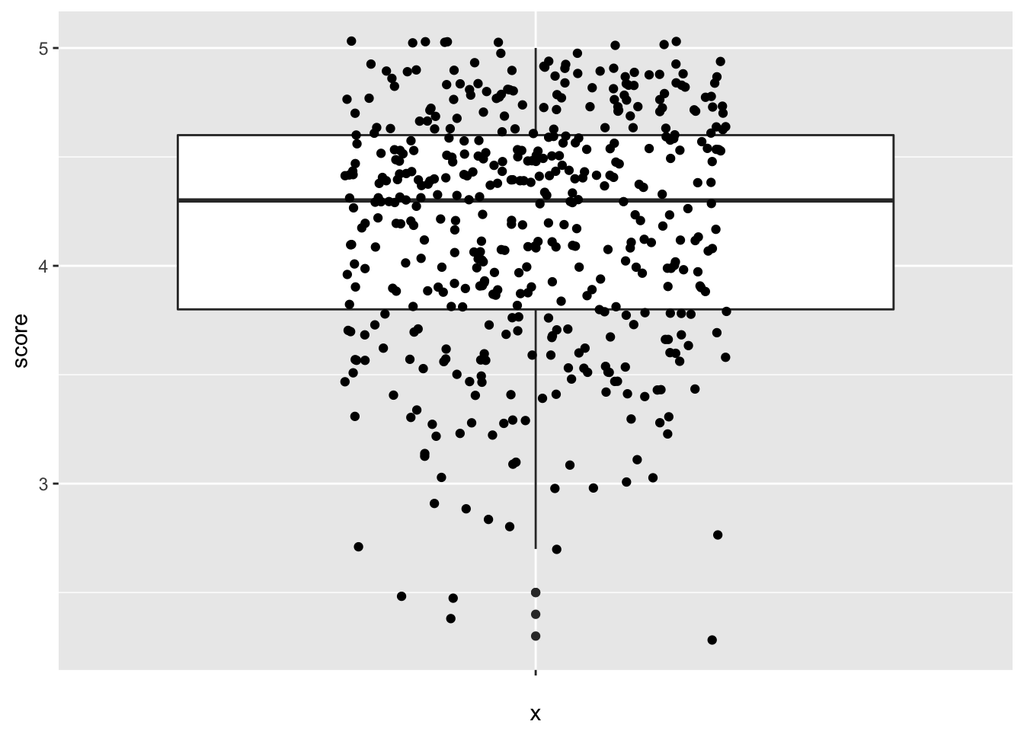

```r
ggplot(eval, aes("", score)) + geom_boxplot() + geom_jitter(width = 0.2)
```

## Regressão Linear Simples - Questão 2

Para iniciar, vamos criar o modelo linear para o *score* baseado em *bty_avg* que é a média de beleza do professor.

```r
mod_simple <- lm(score ~ bty_avg, data = eval)

tidy(mod_simple, conf.int = TRUE)
```

```
##          term   estimate  std.error statistic       p.value   conf.low
## 1 (Intercept) 3.88033795 0.07614297 50.961212 1.561043e-191 3.73070764
## 2     bty_avg 0.06663704 0.01629115  4.090382  5.082731e-05 0.03462292
##    conf.high
## 1 4.02996827
## 2 0.09865116
```

Pela tabela acima, temos que o **p-value = 0.00005082731** (< 0.05), logo podemos afirmar que a *média de beleza* tem um efeito significativo no *score* do professor. Outro indício disso é que o intervalo obtido para a variável *bty_avg* não inclui o 0, sendo ele [0.03462292, 0.09865116]. Porém, esse efeito significativo **não tem uma significânca prática**, já que o *score* é pouco alterado pela *média de beleza*(fator de incremento = 0.06). Como equação do nosso modelo linear temos: score = valor_intercepto_em_y + fator_de_incremento * bty_avg score = 3.88 + 0.06 * bty_avg

```r
glance(mod_simple)
```

```
##    r.squared adj.r.squared     sigma statistic      p.value df    logLik
## 1 0.03502226    0.03292903 0.5348351  16.73123 5.082731e-05  2 -366.2225
##        AIC      BIC deviance df.residual
## 1 738.4449 750.8581 131.8684         461
```

Dessa tabela podemos observar o r.squared = 0.03, que nos indica um fraco grau de associação dessas duas variáveis por estar próximo de 0, confirmando o que já vimos mais acima onde uma sofre pouca influência da outra. De outra forma, nosso modelo linear baseado na variável *bty_avg* só explica 3% do *score*. Abaixo observamos que a reta do modelo tenta se ajustar aos dados mas ainda não temos um resultado tão bom pelo fato dos pontos estarem bastante espalhados.

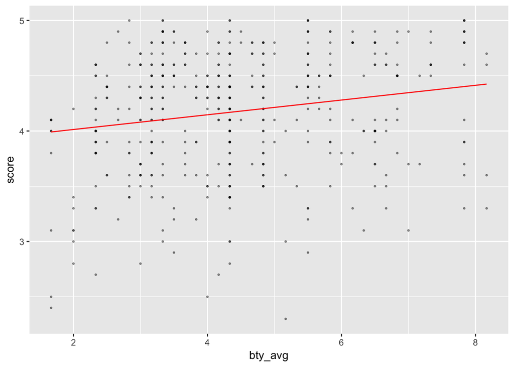

```r
eval %>%
  add_predictions(model = mod_simple) %>%
  ggplot(mapping = aes(x = bty_avg, y = score)) +
  geom_point(alpha = 0.4, size = .5) +
  geom_line(aes(y = pred), colour = "red")
```

Sobre os resíduos temos uma distribuição uniforme deles e não se distanciam muito do 0, porém temos muitos pontos espalhados. Possa ser que realizando transformações nos dados obtivéssemos um resultado melhor.

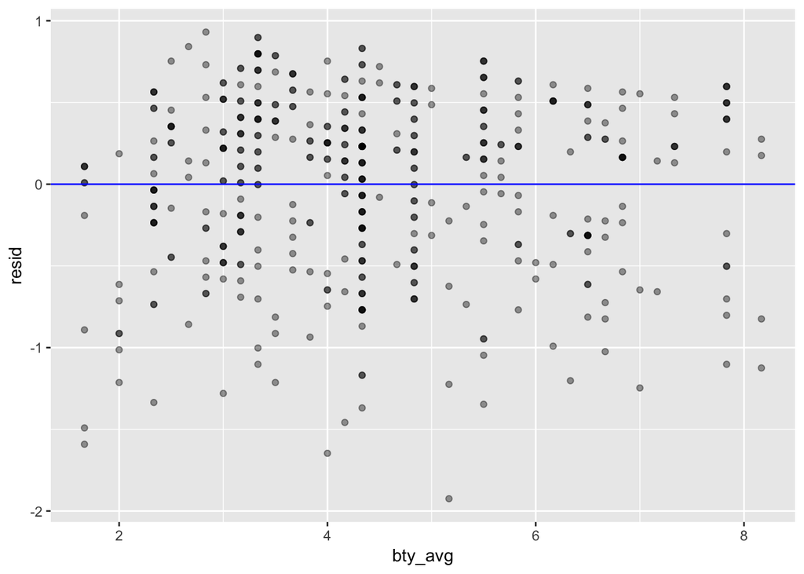

```r
eval %>%
  add_residuals(model = mod_simple) %>%
  ggplot(aes(bty_avg, resid)) +
  geom_point(alpha = .4) +
  geom_hline(yintercept = 0, colour = "blue")
```

## Regressão Linear Múltipla - Questão 3

Aqui vamos analisar o efeito de múltiplas variáveis no score de forma simultânea. Para isso continuaremos analisando a *média de beleza* e adicionaremos o *rank* do professor, supondo que professores com níveis mais altos possuem mais experiência, *age*, supondo que com o passar dos anos os professores vão aprimorando a forma de lecionar e *bty_avg relacionada com a etnia do professor*, pois será que a beleza não seja relativa para o avaliador dependendo da etnia do professor?

```r
mod_multi = lm(score ~ bty_avg + rank + age + bty_avg*ethnicity, data = eval)
tidy(mod_multi, conf.int = TRUE)
```

```
##                            term     estimate   std.error statistic
## 1                   (Intercept)  4.529743254 0.270074254 16.772214
## 2                       bty_avg -0.014805854 0.045857580 -0.322866
## 3              ranktenure track -0.192032100 0.083129018 -2.310049
## 4                   ranktenured -0.103677002 0.062818649 -1.650418
## 5                           age -0.005758581 0.003158381 -1.823270
## 6         ethnicitynot minority -0.273605930 0.235290764 -1.162842
## 7 bty_avg:ethnicitynot minority  0.086157788 0.049315185  1.747084
##        p.value    conf.low     conf.high
## 1 1.585131e-49  3.99899875  5.0604877586
## 2 7.469447e-01 -0.10492425  0.0753125415
## 3 2.133112e-02 -0.35539558 -0.0286686217
## 4 9.954611e-02 -0.22712695  0.0197729460
## 5 6.891710e-02 -0.01196537  0.0004482067
## 6 2.455019e-01 -0.73599462  0.1887827584
## 7 8.129592e-02 -0.01075542  0.1830710006
```

Observando os **p-valores** temos que a única variávei significativa é ranktenure track por aprensentar p-value menor que 0.05. O valor de *ranktenure track* impacta negativamento em *score*, com fator igual a -0.19 quando modificada. Além disso, é possível notar que o impacto de bty_avg diminuiu, indo de 0.06 para -0.01 quando adicionamos a relação bty_avg com ethinocity.

```r
glance(mod_multi)
```

```
##    r.squared adj.r.squared     sigma statistic      p.value df    logLik
## 1 0.06660234    0.05432079 0.5288867   5.42296 1.975807e-05  7 -358.5196
##        AIC     BIC deviance df.residual
## 1 733.0392 766.141 127.5528         456
```

Com a regressão linear multivariada obtivemos um r.squared = 0.06 nos indicando que este modelo ainda não ocnsegue explicar muita coisa do *score*. Tivemos um aumento de 3% obtido na simples para 6% com a multivariada.

Sobre os resíduos encontramos um padrão o qual nos indica que o modelo não foi adequado, por variar muito na predição, hora subestimando, hora superestimando.

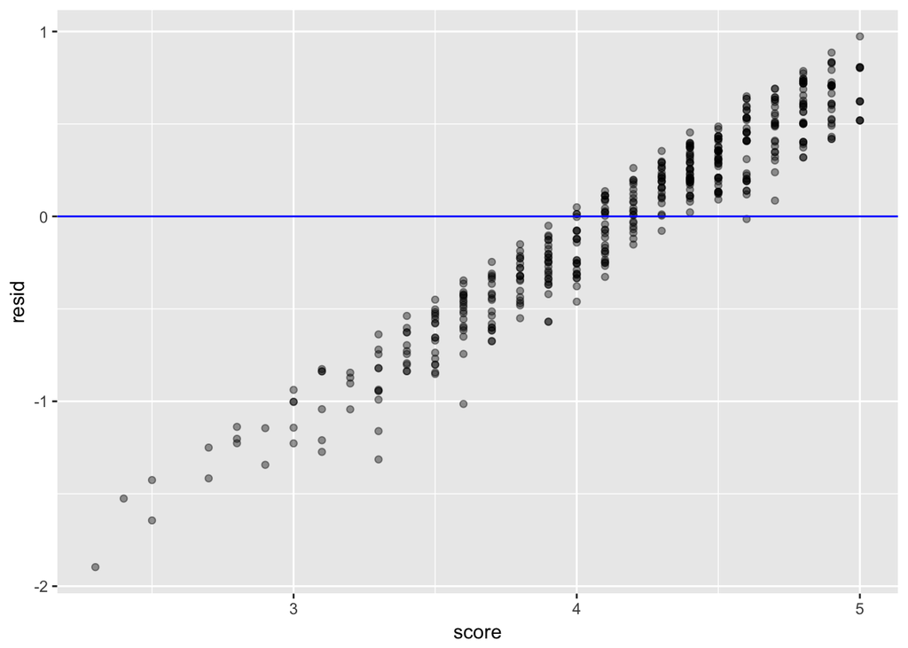

```r
adv_eval = eval %>%
    add_predictions(model = mod_multi) %>%
    add_residuals(model = mod_multi)

adv_eval %>%
  add_residuals(model = mod_multi) %>%
  ggplot(aes(score, resid)) +
  geom_point(alpha = .4) +
  geom_hline(yintercept = 0, colour = "blue")
```

Por fim, notamos que bty_avg tem um impacto insignificante em relação ao score e teríamos que utilizar outras variáveis na tentativa de melhorar o modelo(se é que as variáveis existentes conseguem explicar bem o score).